# Les requêtes multi-tables PostgreSQL

Razvan BIZOÏ

2024-11-23

# Librairies nécessaires

```r
library(RPostgres)
library(DBI)
library(DT)

library(tidyverse)
library(nanoparquet)

library(reticulate)

rm(list=ls())
```

# Connexion à la base de données PostgreSQL `Cours`

```r
library(RPostgres)
library(DBI)

connection <- dbConnect(RPostgres::Postgres(), host=host, port=port, dbname=dbname, user=user, password=password)
```

# La jointure sans condition

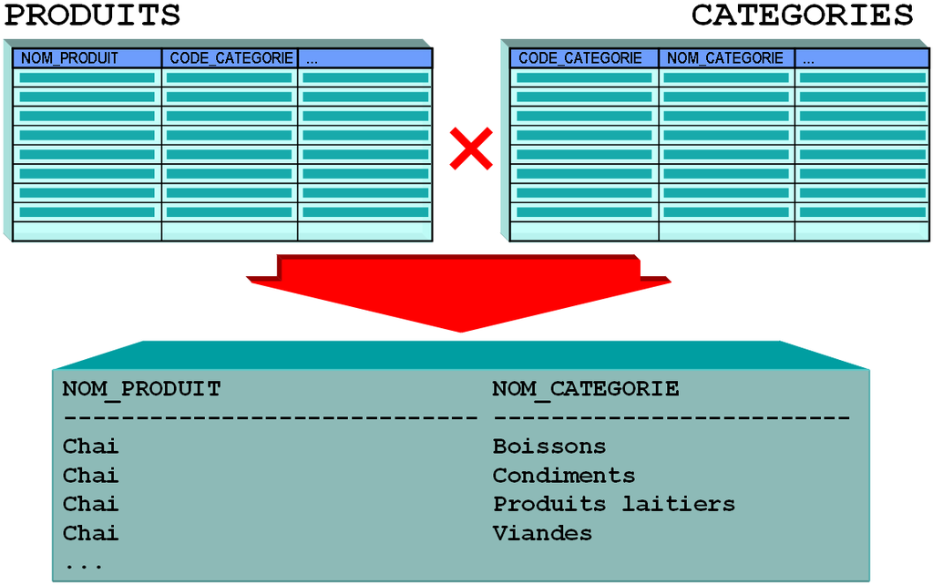

```r
requette <- dbSendQuery(connection, "

              SELECT (SELECT COUNT(*) FROM PRODUITS) as PRODUITS,
                     (SELECT COUNT(*) FROM CATEGORIES) as CATEGORIES,
                     (SELECT count(*) FROM PRODUITS CROSS JOIN CATEGORIES) CROSS_JOIN

                        ")

donnees <- dbFetch(requette);dbHasCompleted(requette);dbClearResult(requette)
```

```
## [1] TRUE
```

```r
donnees
```

```
##   produits categories cross_join
## 1      120         10       1200
```

```r
requette <- dbSendQuery(connection, "

              SELECT NOM_PRODUIT, NOM_CATEGORIE FROM PRODUITS CROSS JOIN CATEGORIES

                        ")

donnees <- dbFetch(requette);dbHasCompleted(requette);dbClearResult(requette)
```

```
## [1] TRUE
```

```r
datatable(donnees,options = list(pageLength = 12, autoWidth = TRUE))
```

|  | nom_produit | nom_categorie |
| --- | --- | --- |
| 1 | Tea | Boissons |
| 2 | Tea | Condiments |
| 3 | Tea | Desserts |
| 4 | Tea | Produits laitiers |
| 5 | Tea | Pâtes et céréales |
| 6 | Tea | Viandes |
| 7 | Tea | Produits secs |
| 8 | Tea | Poissons et fruits de mer |
| 9 | Tea | Conserves |
| 10 | Tea | Viande en conserve |

[output cut: 1190 more lines]

# La jointure avec condition

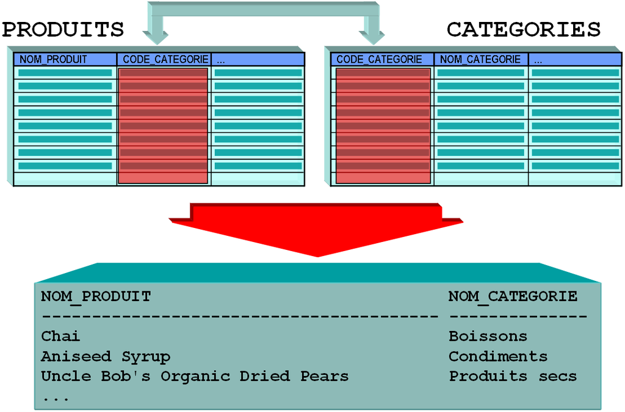

```r
requette <- dbSendQuery(connection, "

              SELECT count(*)
              FROM PRODUITS A
                   JOIN CATEGORIES B
                   ON A.CODE_CATEGORIE = B.CODE_CATEGORIE

                        ")

donnees <- dbFetch(requette);dbHasCompleted(requette);dbClearResult(requette)
```

```
## [1] TRUE
```

```r
donnees
```

```
##   count
## 1   120
```

```r
requette <- dbSendQuery(connection, "

              SELECT A.CODE_CATEGORIE CAT,
                     NOM_PRODUIT Produit,
                     NOM_CATEGORIE Categorie
              FROM PRODUITS A
                   JOIN CATEGORIES B
                   ON A.CODE_CATEGORIE = B.CODE_CATEGORIE
              ORDER BY NOM_PRODUIT

                        ")

donnees <- dbFetch(requette);dbHasCompleted(requette);dbClearResult(requette)
```

```
## [1] TRUE
```

```r
datatable(donnees,options = list(pageLength = 10, autoWidth = TRUE))
```

|  | cat | produit | categorie |
| --- | --- | --- | --- |
| 1 | 6 | Alice Mutton | Viandes |
| 2 | 7 | Amandes | Produits secs |
| 3 | 2 | Aniseed Syrup | Condiments |
| 4 | 1 | Beer | Boissons |
| 5 | 8 | Boston Crab Meat | Poissons et fruits de mer |
| 6 | 9 | Boysenberry Spread | Conserves |
| 7 | 3 | Brownie Mix | Desserts |
| 8 | 2 | Cajun Seasoning | Condiments |
| 9 | 3 | Cake Mix | Desserts |
| 10 | 4 | Camembert Pierrot | Produits laitiers |

[output cut: 110 more lines]

```r
requette <- dbSendQuery(connection, "

              SELECT C.NOM||' '||C.PRENOM Vendeur,
                     A.SOCIETE Client,
                     B.DATE_COMMANDE Commande,
                     B.PORT Port
              FROM CLIENTS A
                   JOIN COMMANDES B
                        ON A.CODE_CLIENT = B.CODE_CLIENT
                   JOIN EMPLOYES C
                        ON B.NO_EMPLOYE  = C.NO_EMPLOYE
              WHERE  B.DATE_COMMANDE > make_date(2011,6,29)
              FETCH FIRST 30 ROWS ONLY

                        ")

donnees <- dbFetch(requette);dbHasCompleted(requette);dbClearResult(requette)
```

```
## [1] TRUE
```

```r
datatable(donnees,options = list(pageLength = 10, autoWidth = TRUE))
```

|  | vendeur | client | commande | port |
| --- | --- | --- | --- | --- |
| 1 | Cazade Anne-Claire | Ernst Handel | 2011-06-30 | 83.9 |
| 2 | Twardowski Colette | Wolski Zajazd | 2011-06-30 | 54.9 |
| 3 | Clement Valérie | Bólido Comidas preparadas | 2011-06-30 | 59.7 |
| 4 | Marielle Michel | QUICK-Stop | 2011-06-30 | 74.8 |
| 5 | Cleret Doris | Océano Atlántico Ltda. | 2011-06-30 | 79.8 |
| 6 | Kessler Marc | North/South | 2011-06-30 | 93.3 |
| 7 | Jenny Michel | Comércio Mineiro | 2011-06-30 | 85.1 |
| 8 | Viry Yvan | Ricardo Adocicados | 2011-06-30 | 64.9 |
| 9 | Marielle Michel | Toms Spezialitäten | 2011-06-30 | 68.2 |
| 10 | Tourtel Nicole | Hungry Owl All-Night Grocers | 2011-06-30 | 66.3 |

[output cut: 15 more lines]

```r
requette <- dbSendQuery(connection, "

                SELECT DC.REF_PRODUIT,
                       COUNT( DISTINCT CO.NO_COMMANDE) COM
                FROM DETAILS_COMMANDES DC
                     JOIN PRODUITS PR
                          ON ( DC.PRIX_UNITAIRE BETWEEN PR.PRIX_UNITAIRE*0.95
                          AND PR.PRIX_UNITAIRE*1.05
                          AND PR.REF_PRODUIT = 57 )
                     JOIN COMMANDES CO
                          ON  ( CO.NO_COMMANDE = DC.NO_COMMANDE
                               AND extract(year from CO.DATE_COMMANDE)   = 2011 )
                     JOIN CLIENTS CL
                     ON  ( CO.CODE_CLIENT = CL.CODE_CLIENT AND CL.PAYS LIKE 'A%')
                GROUP BY DC.REF_PRODUIT

                        ")

donnees <- dbFetch(requette);dbHasCompleted(requette);dbClearResult(requette)
```

```
## [1] TRUE
```

```r
donnees
```

```
##   ref_produit com
## 1          20 276
## 2          62 259
## 3          96 292
## 4         111 228
## 5         120 274
```

```r
requette <- dbSendQuery(connection, "

              SELECT (SELECT COUNT(*) FROM CLIENTS) as CLIENTS,
                     (SELECT COUNT(*) FROM EMPLOYES) as EMPLOYES,
                     (SELECT COUNT(*) FROM PRODUITS) as PRODUITS,
                     (SELECT COUNT(*) FROM FOURNISSEURS) as FOURNISSEURS,
                     (SELECT COUNT(*) FROM CATEGORIES) as CATEGORIES,
                     (SELECT COUNT(*) FROM COMMANDES) as COMMANDES,
                     (SELECT COUNT(*) FROM DETAILS_COMMANDES) as DETAILS_COMMANDES

                        ")

donnees <- dbFetch(requette);dbHasCompleted(requette);dbClearResult(requette)
```

```
## [1] TRUE
```

```r
donnees
```

```
##   clients employes produits fournisseurs categories commandes details_commandes
## 1      91      111      120           29         10     13462            476091
```

```r
requette <- dbSendQuery(connection, "

                  SELECT COUNT(*)
                  FROM CLIENTS CL
                       JOIN COMMANDES CO
                          ON ( CL.CODE_CLIENT = CO.CODE_CLIENT)
                       JOIN EMPLOYES EM
                          ON ( EM.NO_EMPLOYE = CO.NO_EMPLOYE)
                       JOIN DETAILS_COMMANDES DC
                          ON ( CO.NO_COMMANDE = DC.NO_COMMANDE)
                       JOIN PRODUITS PR
                          ON ( DC.REF_PRODUIT = PR.REF_PRODUIT)
                       JOIN FOURNISSEURS FR
                          ON ( PR.NO_FOURNISSEUR = FR.NO_FOURNISSEUR )
                       JOIN CATEGORIES CA
                          ON ( PR.CODE_CATEGORIE = CA.CODE_CATEGORIE )

                        ")

donnees <- dbFetch(requette);dbHasCompleted(requette);dbClearResult(requette)
```

```
## [1] TRUE
```

```r
donnees
```

```
##    count
## 1 476091
```

# La jointure externe

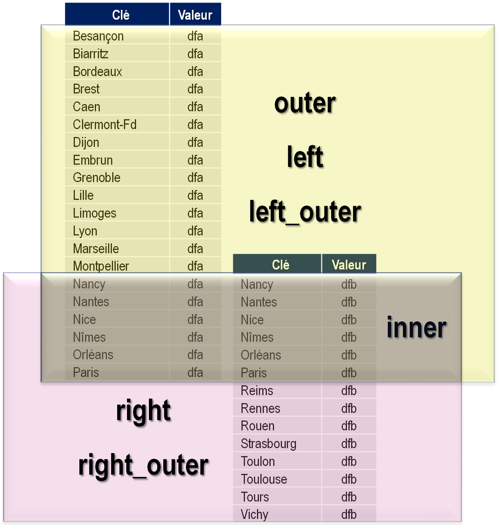

## `INNER JOIN`

```r
requette <- dbSendQuery(connection, "

                  SELECT COALESCE(C.VILLE,F.VILLE) VILLE,
                         COALESCE(C.SOCIETE,'-------') CLIENT,
                         COALESCE(F.SOCIETE,'-------') FOURNISSEUR
                  FROM CLIENTS C INNER JOIN FOURNISSEURS F
                       ON C.VILLE = F.VILLE
                  ORDER BY VILLE

                        ")

donnees <- dbFetch(requette);dbHasCompleted(requette);dbClearResult(requette)
```

```
## [1] TRUE
```

```r
datatable(donnees,options = list(pageLength = 12, autoWidth = TRUE))
```

|  | ville | client | fournisseur |
| --- | --- | --- | --- |
| 1 | Berlin | Alfreds Futterkiste | Heli Süßwaren GmbH Co. KG |
| 2 | Frankfurt a.M. | Lehmanns Marktstand | Plutzer Lebensmittelgroßmärkte AG |
| 3 | London | B's Beverages | Exotic Liquids |
| 4 | London | Consolidated Holdings | Exotic Liquids |
| 5 | London | Eastern Connection | Exotic Liquids |
| 6 | London | Seven Seas Imports | Exotic Liquids |
| 7 | London | Around the Horn | Exotic Liquids |
| 8 | London | North/South | Exotic Liquids |
| 9 | Montréal | Mère Paillarde | Ma Maison |
| 10 | Paris | Spécialités du monde | Aux joyeux ecclésiastiques |

[output cut: 5 more lines]

## `LEFT OUTER JOIN`

```r
requette <- dbSendQuery(connection, "

                  SELECT COALESCE(C.VILLE,F.VILLE) VILLE,
                         COALESCE(C.SOCIETE,'-------') CLIENT,
                         COALESCE(F.SOCIETE,'-------') FOURNISSEUR
                  FROM CLIENTS C LEFT OUTER JOIN FOURNISSEURS F
                       ON C.VILLE = F.VILLE
                  ORDER BY VILLE

                        ")

donnees <- dbFetch(requette);dbHasCompleted(requette);dbClearResult(requette)
```

```
## [1] TRUE
```

```r
datatable(donnees,options = list(pageLength = 12, autoWidth = TRUE))
```

|  | ville | client | fournisseur |
| --- | --- | --- | --- |
| 1 | Aachen | Drachenblut Delikatessen | ------- |
| 2 | Albuquerque | Rattlesnake Canyon Grocery | ------- |
| 3 | Anchorage | Old World Delicatessen | ------- |
| 4 | Århus | Vaffeljernet | ------- |
| 5 | Barcelona | Galería del gastrónomo | ------- |
| 6 | Barquisimeto | LILA-Supermercado | ------- |
| 7 | Bergamo | Magazzini Alimentari Riuniti | ------- |
| 8 | Berlin | Alfreds Futterkiste | Heli Süßwaren GmbH Co. KG |
| 9 | Bern | Chop-suey Chinese | ------- |
| 10 | Boise | Save-a-lot Markets | ------- |

[output cut: 81 more lines]

## `RIGHT OUTER JOIN`

```r
requette <- dbSendQuery(connection, "

                  SELECT COALESCE(C.VILLE,F.VILLE) VILLE,
                         COALESCE(C.SOCIETE,'-------') CLIENT,
                         COALESCE(F.SOCIETE,'-------') FOURNISSEUR
                  FROM CLIENTS C RIGHT OUTER JOIN FOURNISSEURS F
                       ON C.VILLE = F.VILLE
                  ORDER BY VILLE

                        ")

donnees <- dbFetch(requette);dbHasCompleted(requette);dbClearResult(requette)
```

```
## [1] TRUE
```

```r
datatable(donnees,options = list(pageLength = 12, autoWidth = TRUE))
```

|  | ville | client | fournisseur |
| --- | --- | --- | --- |
| 1 | Ann Arbor | ------- | Grandma Kelly's Homestead |
| 2 | Annecy | ------- | Gai pâturage |
| 3 | Bend | ------- | Bigfoot Breweries |
| 4 | Berlin | Alfreds Futterkiste | Heli Süßwaren GmbH Co. KG |
| 5 | Boston | ------- | New England Seafood Cannery |
| 6 | Cuxhaven | ------- | Nord-Ost-Fisch Handelsgesellschaft mbH |
| 7 | Frankfurt a.M. | Lehmanns Marktstand | Plutzer Lebensmittelgroßmärkte AG |
| 8 | Göteborg | ------- | PB Knäckebröd AB |
| 9 | Lappeenranta | ------- | Karkki Oy |
| 10 | London | Around the Horn | Exotic Liquids |

[output cut: 28 more lines]

## `FULL OUTER JOIN`

```r
requette <- dbSendQuery(connection, "

                  SELECT COALESCE(C.VILLE,F.VILLE) VILLE,
                         COALESCE(C.SOCIETE,'-------') CLIENT,
                         COALESCE(F.SOCIETE,'-------') FOURNISSEUR
                  FROM CLIENTS C FULL OUTER JOIN FOURNISSEURS F
                       ON C.VILLE = F.VILLE
                  ORDER BY VILLE

                        ")

donnees <- dbFetch(requette);dbHasCompleted(requette);dbClearResult(requette)
```

```
## [1] TRUE
```

```r
datatable(donnees,options = list(pageLength = 12, autoWidth = TRUE))
```

|  | ville | client | fournisseur |
| --- | --- | --- | --- |
| 1 | Aachen | Drachenblut Delikatessen | ------- |
| 2 | Albuquerque | Rattlesnake Canyon Grocery | ------- |
| 3 | Anchorage | Old World Delicatessen | ------- |
| 4 | Ann Arbor | ------- | Grandma Kelly's Homestead |
| 5 | Annecy | ------- | Gai pâturage |
| 6 | Århus | Vaffeljernet | ------- |
| 7 | Barcelona | Galería del gastrónomo | ------- |
| 8 | Barquisimeto | LILA-Supermercado | ------- |
| 9 | Bend | ------- | Bigfoot Breweries |
| 10 | Bergamo | Magazzini Alimentari Riuniti | ------- |

[output cut: 104 more lines]

## Predicats

```r
requette <- dbSendQuery(connection, "

                  SELECT COUNT(distinct co.no_employe) employes_commandes,
                         COUNT(distinct em.no_employe) employes_total
                  FROM COMMANDES CO
                       RIGHT JOIN EMPLOYES EM
                          ON ( EM.NO_EMPLOYE = CO.NO_EMPLOYE)

                        ")

donnees <- dbFetch(requette);dbHasCompleted(requette);dbClearResult(requette)
```

```
## [1] TRUE
```

```r
donnees
```

```
##   employes_commandes employes_total
## 1                 92            111
```

```r
requette <- dbSendQuery(connection, "

                  SELECT COUNT(distinct co.no_employe) employes_commandes,
                         COUNT(distinct em.no_employe) employes_total
                  FROM COMMANDES CO
                       RIGHT JOIN EMPLOYES EM
                          ON ( EM.NO_EMPLOYE = CO.NO_EMPLOYE)
                  WHERE CO.CODE_CLIENT = 'ALFKI'

                        ")

donnees <- dbFetch(requette);dbHasCompleted(requette);dbClearResult(requette)
```

```
## [1] TRUE
```

```r
donnees
```

```
##   employes_commandes employes_total
## 1                  7              7
```

```r
requette <- dbSendQuery(connection, "

                  SELECT COUNT(distinct co.no_employe) employes_commandes,
                         COUNT(distinct em.no_employe) employes_total
                  FROM COMMANDES CO
                       RIGHT JOIN EMPLOYES EM
                          ON ( EM.NO_EMPLOYE = CO.NO_EMPLOYE
                            AND CO.CODE_CLIENT = 'ALFKI' )

                        ")

donnees <- dbFetch(requette);dbHasCompleted(requette);dbClearResult(requette)
```

```
## [1] TRUE
```

```r
donnees
```

```
##   employes_commandes employes_total
## 1                  7            111
```

# Atelier 1 – Les requêtes multi-tables

## Les équijointures

Écrivez les requêtes vous permettant d’afficher :

1. Le nom, le prénom et la société cliente pour les employés qui ont effectué une vente pour les clients de Paris.
2. La société cliente, le nombre des produits commandés, la ville et le pays qui ont commandé plus de 115 références de produits au mois de mai 2011. (`EXTRACT(YEAR FROM DATE_COMMANDE)` et `EXTRACT(MONTH FROM DATE_COMMANDE)` ou `TO_CHAR(DATE_COMMANDE,'YYYYMM')`)
3. Le nom de la catégorie du produit, la société fournisseur et le nom du produit, uniquement pour les produits des catégories 1, 4 et 7.
4. La société cliente, la société fournisseur et leur ville pour les clients qui sont localisés dans une ville d’un fournisseur (Il s’agit d’une jointure entre la table `CLIENTS` et `FOURNISSEURS`).
5. Les sociétés clientes qui ont commandé le produit `'Chai'`.

## Les jointures externes

Écrivez les requêtes permettant d’afficher :

1. Tous les clients et le cumul des quantités vendues pour les clients qui ont passé des commandes au `01/mai/2011`. Affichez les enregistrements par ordre décroissant de cumul des commandes avec les valeurs `NULL` à la fin.
2. Le nom, le prénom, la fonction de tous les employés, la somme des frais de port et le cumul des ventes (prix unitaire fois la quantité) pour les employés qui ont passé des commandes. Affichez les enregistrements par ordre décroissant de cumul des ventes avec les valeurs `NULL` à la fin.

# Jointures DataFrame R

```r
requette <- dbSendQuery(connection, "select * from commandes")
commandes <- dbFetch(requette);dbHasCompleted(requette);dbClearResult(requette)
```

```
## [1] TRUE
```

```r
commandes %>% write_parquet(
  '../donnees/donnees_commandes.gzip',
  compression = "gzip",
  options = parquet_options()
)

requette <- dbSendQuery(connection, "select * from employes")
employes <- dbFetch(requette);dbHasCompleted(requette);dbClearResult(requette)
```

```
## [1] TRUE
```

```r
employes %>% write_parquet(
  '../donnees/donnees_employes.gzip',
  compression = "gzip",
  options = parquet_options()
)

requette <- dbSendQuery(connection, "select * from clients")
clients <- dbFetch(requette);dbHasCompleted(requette);dbClearResult(requette)
```

```
## [1] TRUE
```

```r
clients %>% write_parquet(
  '../donnees/donnees_clients.gzip',
  compression = "gzip",
  options = parquet_options()
)

requette <- dbSendQuery(connection, "select * from fournisseurs")
fournisseurs <- dbFetch(requette);dbHasCompleted(requette);dbClearResult(requette)
```

```
## [1] TRUE
```

```r
fournisseurs %>% write_parquet(
  '../donnees/donnees_fournisseurs.gzip',
  compression = "gzip",
  options = parquet_options()
)
```

## `INNER JOIN`

```r
clients %>%
  transmute(ville = ville,
            client = societe) %>%
  inner_join(fournisseurs %>%
              transmute(ville = ville,
                        fournisseur = societe)
              ,by=c("ville" = "ville")) %>%
  arrange( ville ) %>%
  head(20) -> resultat
```

```r
datatable(resultat,options = list(pageLength = 10, autoWidth = TRUE))
```

|  | ville | client | fournisseur |
| --- | --- | --- | --- |
| 1 | Berlin | Alfreds Futterkiste | Heli Süßwaren GmbH Co. KG |
| 2 | Frankfurt a.M. | Lehmanns Marktstand | Plutzer Lebensmittelgroßmärkte AG |
| 3 | London | Consolidated Holdings | Exotic Liquids |
| 4 | London | Eastern Connection | Exotic Liquids |
| 5 | London | North/South | Exotic Liquids |
| 6 | London | Seven Seas Imports | Exotic Liquids |
| 7 | London | Around the Horn | Exotic Liquids |
| 8 | London | B's Beverages | Exotic Liquids |
| 9 | Montréal | Mère Paillarde | Ma Maison |
| 10 | Paris | Paris spécialités | Aux joyeux ecclésiastiques |

[output cut: 5 more lines]

## `LEFT OUTER JOIN`

```r
clients %>%
  transmute(ville = ville,
            client = societe) %>%
  left_join(fournisseurs %>%
              transmute(ville = ville,
                        fournisseur = societe)
              ,by=c("ville" = "ville")) %>%
  arrange( ville ) %>%
  head(20) -> resultat
```

```r
datatable(resultat,options = list(pageLength = 10, autoWidth = TRUE))
```

|  | ville | client | fournisseur |
| --- | --- | --- | --- |
| 1 | Aachen | Drachenblut Delikatessen |  |
| 2 | Albuquerque | Rattlesnake Canyon Grocery |  |
| 3 | Anchorage | Old World Delicatessen |  |
| 4 | Barcelona | Galería del gastrónomo |  |
| 5 | Barquisimeto | LILA-Supermercado |  |
| 6 | Bergamo | Magazzini Alimentari Riuniti |  |
| 7 | Berlin | Alfreds Futterkiste | Heli Süßwaren GmbH Co. KG |
| 8 | Bern | Chop-suey Chinese |  |
| 9 | Boise | Save-a-lot Markets |  |
| 10 | Brandenburg | Königlich Essen |  |

[output cut: 10 more lines]

## `RIGHT OUTER JOIN`

```r
clients %>%
  transmute(ville = ville,
            client = societe) %>%
  right_join(fournisseurs %>%
              transmute(ville = ville,
                        fournisseur = societe)
              ,by=c("ville" = "ville")) %>%
  arrange( ville ) %>%
  head(20) -> resultat
```

```r
datatable(resultat,options = list(pageLength = 10, autoWidth = TRUE))
```

|  | ville | client | fournisseur |
| --- | --- | --- | --- |
| 1 | Ann Arbor |  | Grandma Kelly's Homestead |
| 2 | Annecy |  | Gai pâturage |
| 3 | Bend |  | Bigfoot Breweries |
| 4 | Berlin | Alfreds Futterkiste | Heli Süßwaren GmbH Co. KG |
| 5 | Boston |  | New England Seafood Cannery |
| 6 | Cuxhaven |  | Nord-Ost-Fisch Handelsgesellschaft mbH |
| 7 | Frankfurt a.M. | Lehmanns Marktstand | Plutzer Lebensmittelgroßmärkte AG |
| 8 | Göteborg |  | PB Knäckebröd AB |
| 9 | Lappeenranta |  | Karkki Oy |
| 10 | London | Consolidated Holdings | Exotic Liquids |

[output cut: 10 more lines]

## `FULL OUTER JOIN`

```r
clients %>%
  transmute(ville = ville,
            client = societe) %>%
  full_join(fournisseurs %>%
              transmute(ville = ville,
                        fournisseur = societe)
              ,by=c("ville" = "ville")) %>%
  arrange( ville ) %>%
  head(20) -> resultat
```

```r
datatable(resultat,options = list(pageLength = 10, autoWidth = TRUE))
```

|  | ville | client | fournisseur |
| --- | --- | --- | --- |
| 1 | Aachen | Drachenblut Delikatessen |  |
| 2 | Albuquerque | Rattlesnake Canyon Grocery |  |
| 3 | Anchorage | Old World Delicatessen |  |
| 4 | Ann Arbor |  | Grandma Kelly's Homestead |
| 5 | Annecy |  | Gai pâturage |
| 6 | Barcelona | Galería del gastrónomo |  |
| 7 | Barquisimeto | LILA-Supermercado |  |
| 8 | Bend |  | Bigfoot Breweries |
| 9 | Bergamo | Magazzini Alimentari Riuniti |  |
| 10 | Berlin | Alfreds Futterkiste | Heli Süßwaren GmbH Co. KG |

[output cut: 10 more lines]

## Jointures externes multiples R

```r
employes %>%
  inner_join(commandes,by=c("no_employe" = "no_employe")) %>%
  inner_join(clients,by=c("code_client" = "code_client")) %>%
  distinct(no_employe) %>%
  summarize( n = n())
```

```
##    n
## 1 92
```

```r
employes %>%
  left_join(commandes,by=c("no_employe" = "no_employe")) %>%
  left_join(clients,by=c("code_client" = "code_client")) %>%
  distinct(no_employe) %>%
  summarize( n = n())
```

```
##     n
## 1 111
```

```r
employes %>%
  left_join(commandes,by=c("no_employe" = "no_employe")) %>%
  inner_join(clients,by=c("code_client" = "code_client")) %>%
  distinct(no_employe) %>%
  summarize( n = n())
```

```
##    n
## 1 92
```

```r
commandes %>%
  inner_join(clients,by=c("code_client" = "code_client")) %>%
  right_join(employes,by=c("no_employe" = "no_employe")) %>%
  distinct(no_employe) %>%
  summarize( n = n())
```

```
##     n
## 1 111
```

# Jointures DataFrame Python

```python
import pandas as pd
clients      = pd.read_parquet('../donnees/donnees_clients.gzip'
                         )[['societe','ville']].rename(columns={'societe':'client'})
fournisseurs = pd.read_parquet('../donnees/donnees_fournisseurs.gzip'
                         )[['societe','ville']].rename(columns={'societe':'fournisseur'})
```

## `INNER JOIN`

```python
clients.merge(fournisseurs, on='ville', how='inner').head(10)
```

```
##                   client           ville                        fournisseur
## 0  Consolidated Holdings          London                     Exotic Liquids
## 1     Eastern Connection          London                     Exotic Liquids
## 2     Familia Arquibaldo       São Paulo          Refrescos Americanas LTDA
## 3    Lehmanns Marktstand  Frankfurt a.M.  Plutzer Lebensmittelgroßmärkte AG
## 4         Mère Paillarde        Montréal                          Ma Maison
## 5            North/South          London                     Exotic Liquids
## 6      Paris spécialités           Paris         Aux joyeux ecclésiastiques
## 7          Queen Cozinha       São Paulo          Refrescos Americanas LTDA
## 8     Seven Seas Imports          London                     Exotic Liquids
## 9   Spécialités du monde           Paris         Aux joyeux ecclésiastiques
```

## `LEFT OUTER JOIN`

```python
clients.merge(fournisseurs, on='ville', how='left').head(10)
```

```
##                                  client      ville                fournisseur
## 0                 Consolidated Holdings     London             Exotic Liquids
## 1              Drachenblut Delikatessen     Aachen                        NaN
## 2                       Du monde entier     Nantes                        NaN
## 3                    Eastern Connection     London             Exotic Liquids
## 4                          Ernst Handel       Graz                        NaN
## 5                    Familia Arquibaldo  São Paulo  Refrescos Americanas LTDA
## 6  FISSA Fabrica Inter. Salchichas S.A.     Madrid                        NaN
## 7                     Folies gourmandes      Lille                        NaN
## 8                        Folk och fä HB     Bräcke                        NaN
## 9                        Frankenversand    München                        NaN
```

## `RIGHT OUTER JOIN`

```python
clients.merge(fournisseurs, on='ville', how='right').head(10)
```

```
##                   client             ville                         fournisseur
## 0  Consolidated Holdings            London                      Exotic Liquids
## 1     Eastern Connection            London                      Exotic Liquids
## 2            North/South            London                      Exotic Liquids
## 3     Seven Seas Imports            London                      Exotic Liquids
## 4        Around the Horn            London                      Exotic Liquids
## 5          B's Beverages            London                      Exotic Liquids
## 6                    NaN  Nouvelle-Orléans     Nouvelle-Orléans Cajun Delights
## 7                    NaN         Ann Arbor           Grandma Kelly's Homestead
## 8                    NaN             Tokyo                       Tokyo Traders
## 9                    NaN            Oviedo  Cooperativa de Quesos 'Las Cabras'
```

## `FULL OUTER JOIN`

```python
clients.merge(fournisseurs, on='ville', how='outer').head(10)
```

```
##                          client         ville                 fournisseur
## 0      Drachenblut Delikatessen        Aachen                         NaN
## 1    Rattlesnake Canyon Grocery   Albuquerque                         NaN
## 2        Old World Delicatessen     Anchorage                         NaN
## 3                           NaN     Ann Arbor   Grandma Kelly's Homestead
## 4                           NaN        Annecy                Gai pâturage
## 5        Galería del gastrónomo     Barcelona                         NaN
## 6             LILA-Supermercado  Barquisimeto                         NaN
## 7                           NaN          Bend           Bigfoot Breweries
## 8  Magazzini Alimentari Riuniti       Bergamo                         NaN
## 9           Alfreds Futterkiste        Berlin  Heli Süßwaren GmbH  Co. KG
```